# Лабораторная работа №1

Имитационное моделирование

бахи сиди али темассини

1032234211@rudn.ru

Российский университет дружбы народов

2026-09-30

# Информация

## Докладчик

- бахи сиди али темассини
- Российский университет дружбы народов

# Цель работы

- Подготовить рабочее окружение для имитационного моделирования.
- Освоить организацию проекта на языке Julia.
- Реализовать модель экспоненциального роста.
- Провести вычислительные эксперименты для различных значений параметра роста.
- Проанализировать полученные результаты.

# Настройка Git и средств аутентификации

## Базовая настройка Git

- Проверена установка Git.
- Установлен GitHub CLI.
- Настроены глобальные параметры Git.

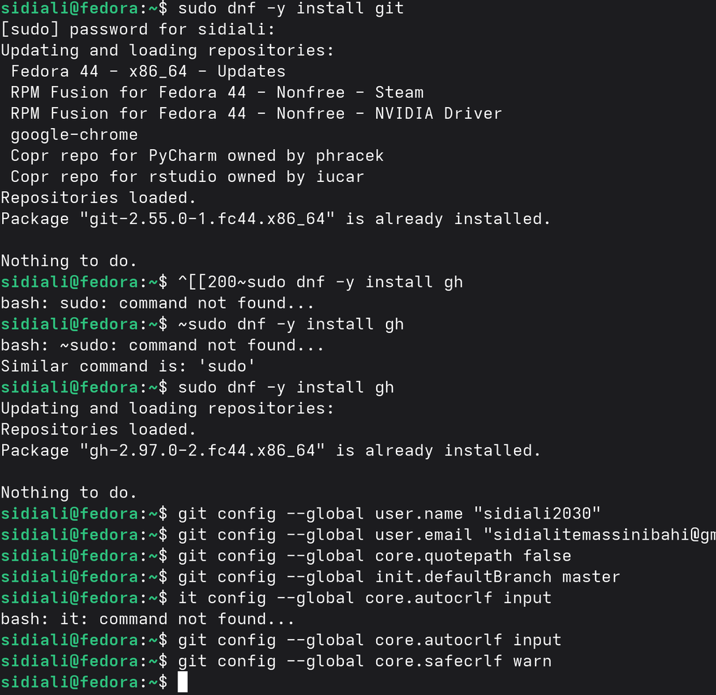

Рисунок 1: Установка GitHub CLI и базовая настройка Git

## Аутентификация на GitHub

- Выполнена аутентификация через GitHub CLI.
- Настроен протокол HTTPS для операций Git.

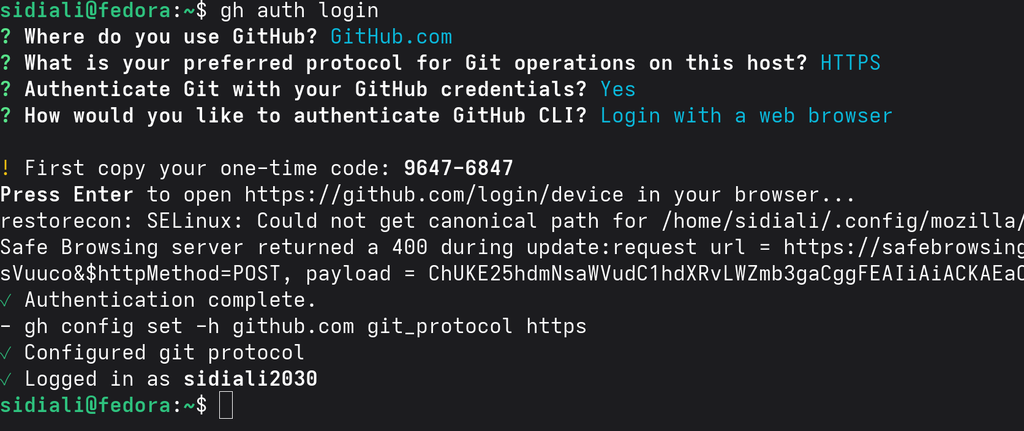

Рисунок 2: Успешная аутентификация на GitHub через GitHub CLI

## Создание SSH-ключа

- Проверено состояние авторизации командой `gh auth status`.
- Создана пара SSH-ключей Ed25519.

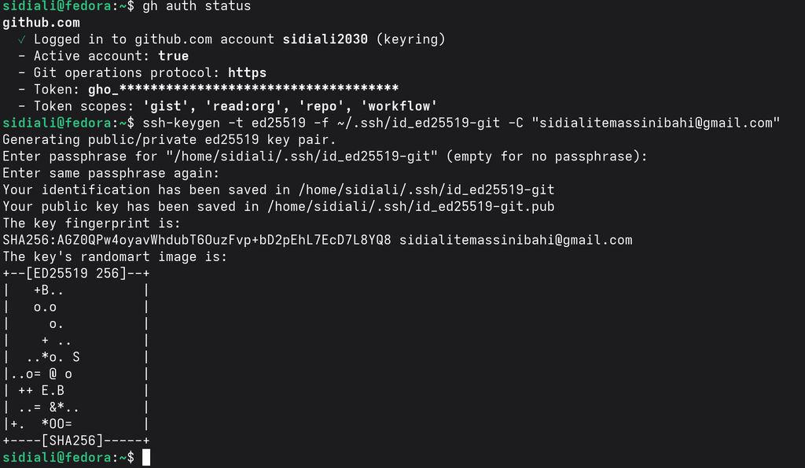

Рисунок 3: Проверка авторизации GitHub и создание SSH-ключа Ed25519

## Создание GPG-ключа

- Создан GPG-ключ с данными пользователя.
- Созданы открытый и секретный ключи.

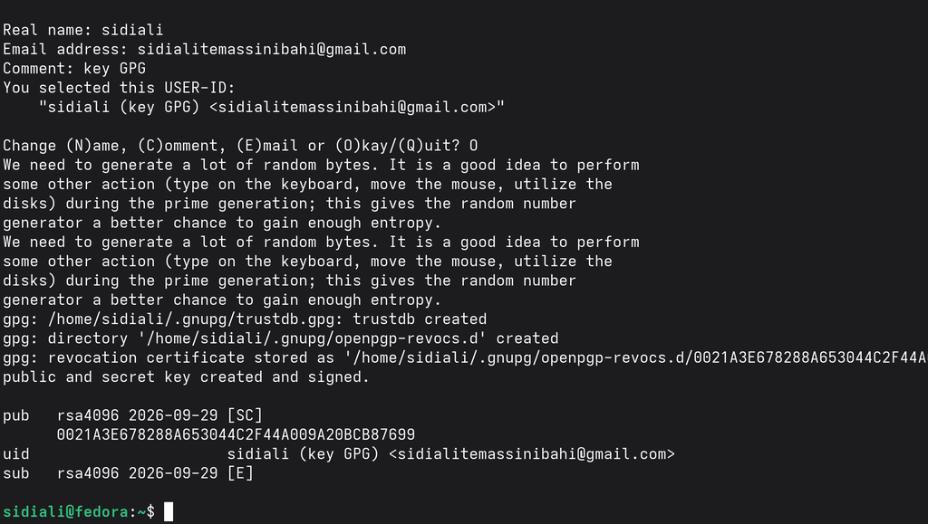

Рисунок 4: Создание GPG-ключа для подписания коммитов

## Настройка GPG-подписания

- Проверен созданный GPG-ключ.
- Настроено автоматическое GPG-подписание коммитов.

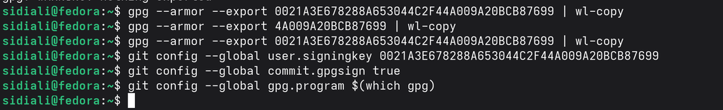

Рисунок 5: Настройка GPG-подписания коммитов Git

## Проверка инструментов

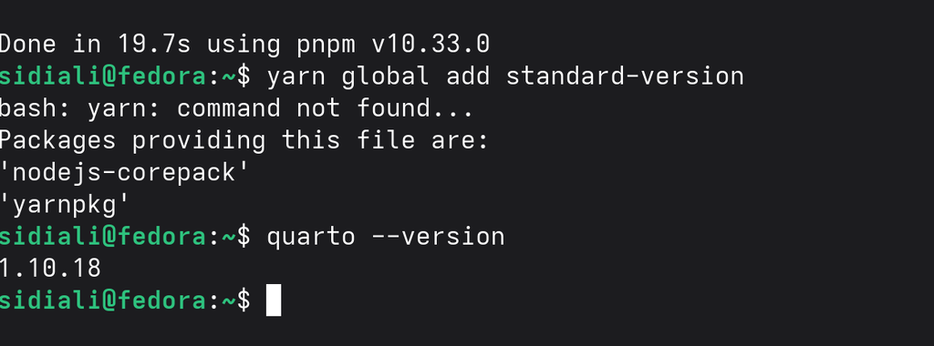

Рисунок 6: Проверка версий и установленных инструментов рабочего окружения

# Подготовка рабочего пространства лабораторной работы

## Клонирование репозитория

- Репозиторий курса клонирован с GitVerse по SSH.
- Создана локальная копия проекта.

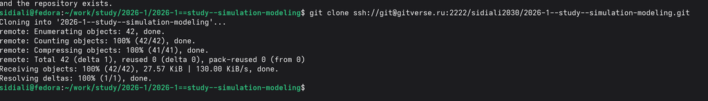

Рисунок 7: Клонирование репозитория курса с GitVerse

## Подготовка структуры проекта

- Выполнена команда `make prepare`.
- Загружены подмодули шаблонов презентации и отчёта.
- Проверена структура лабораторных работ.

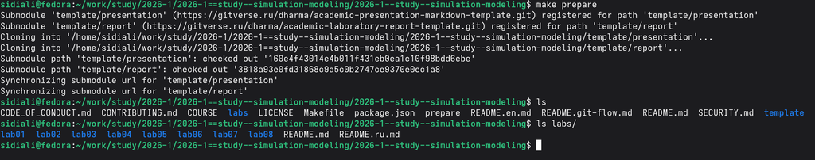

Рисунок 8: Подготовка проекта и проверка структуры лабораторных работ

## Синхронизация с GitVerse

- Изменения отправлены в GitVerse.
- Ветка `master` синхронизирована с `origin/master`.
- Рабочее дерево не содержит изменений.

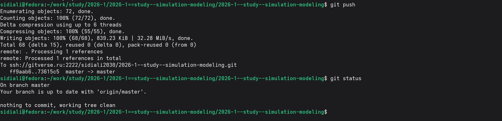

Рисунок 9: Отправка изменений в GitVerse и проверка состояния репозитория

## Синхронизация с GitHub

- Ветка `master` отправлена в репозиторий GitHub.

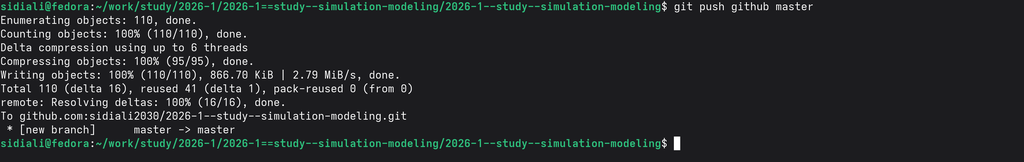

Рисунок 10: Отправка ветки master в удалённый репозиторий GitHub

## Инициализация Git Flow

- Инициализирован Git Flow.
- Основная ветка — `master`.
- Ветка разработки — `develop`.
- Префикс тегов версий — `v`.

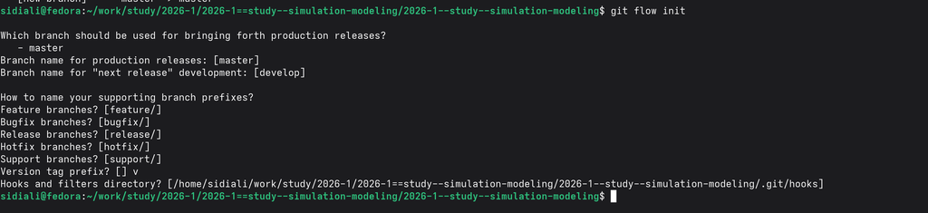

Рисунок 11: Инициализация и настройка Git Flow

## Создание релиза

- Ветки и тег `v1.0.0` отправлены в GitVerse и GitHub.
- Сформирован `CHANGELOG.md`.
- Создан релиз `v1.0.0`.

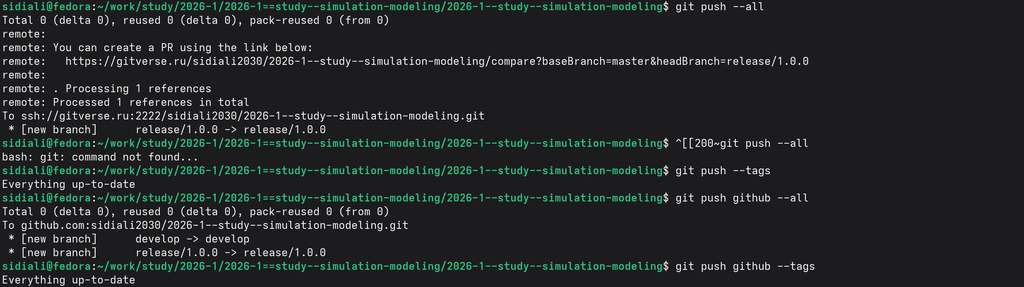

Рисунок 12: Публикация веток и тега v1.0.0 и создание релиза

# Создание и проверка проекта моделирования

## Создание проекта Julia

- Создан каталог `project`.
- Проверена структура проекта.
- Созданы каталоги `data`, `notebooks`, `plots`, `scripts`, `src` и `test`.

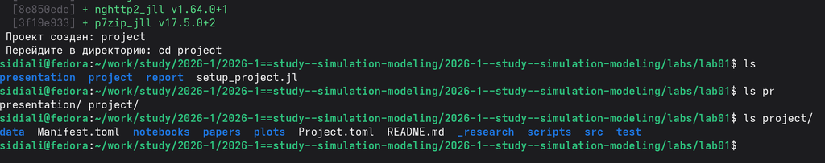

Рисунок 13: Создание и проверка структуры проекта Julia

## Установка зависимостей

- Установлены зависимости Julia.
- Выполнена предварительная компиляция пакетов.

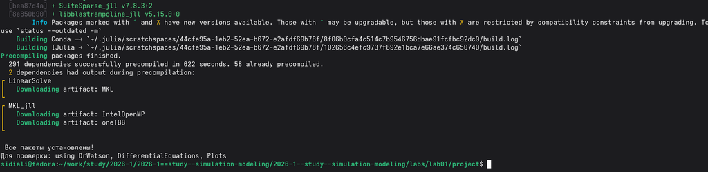

Рисунок 14: Установка и предварительная компиляция пакетов Julia

## Проверка окружения

- Выполнен `scripts/test_setup.jl`.
- Проверена доступность необходимых пакетов.
- Проверена структура каталогов проекта.

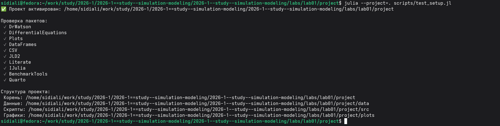

Рисунок 15: Проверка окружения и установленных пакетов проекта

# Реализация модели экспоненциального роста

## Выполнение модели

- Создан сценарий `01_exponential_growth.jl`.
- Получены первые значения решения модели.
- Рассчитано время удвоения: `2.31`.

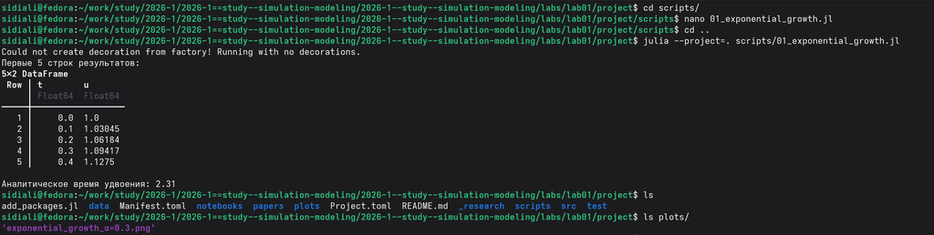

Рисунок 16: Выполнение модели экспоненциального роста

## Визуализация модели

- Построен график для `α = 0.3`.
- Получен экспоненциальный рост популяции во времени.

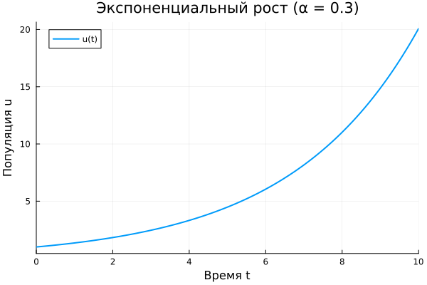

Рисунок 17: График модели экспоненциального роста при α = 0.3

## Сохранение результатов

- Результаты сохранены в `all_results.jld2`.
- График сохранён в каталоге результатов.

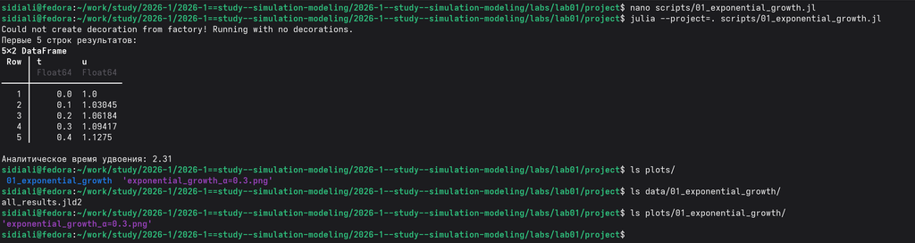

Рисунок 18: Проверка сохранённых данных и графика модели

# Литературная реализация модели

## Генерация файлов

- Подготовлен сценарий `tangle.jl`.
- Сформирован чистый код Julia.
- Созданы документы `.qmd` и `.ipynb`.

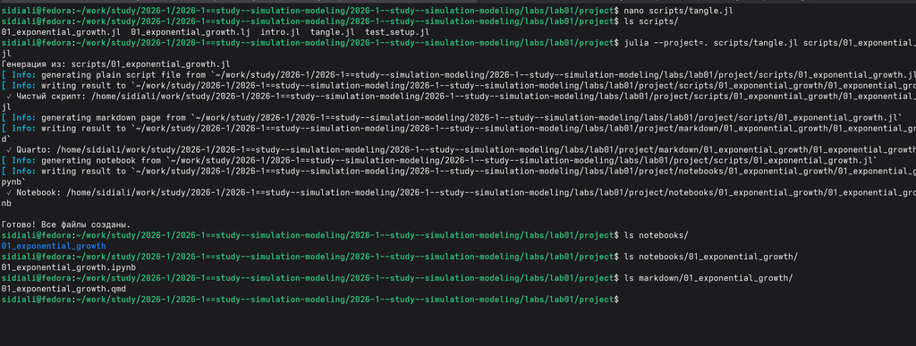

Рисунок 19: Генерация кода, документации Quarto и Jupyter Notebook

## Выполнение Jupyter Notebook

- Выполнен `01_exponential_growth.ipynb`.
- Получены график и таблица результатов.
- Получено время удвоения `2.31`.

[figure not shown]

Рисунок 20: Выполнение модели экспоненциального роста в Jupyter Notebook

# Проведение вычислительного эксперимента

## Параметрическое сканирование

- Выполнен `02_exponential_growth.jl`.
- Базовый эксперимент проведён при `α = 0.3`.
- Исследованы `α = 0.1, 0.3, 0.5, 0.8, 1.0`.
- Результаты сведены в таблицу.

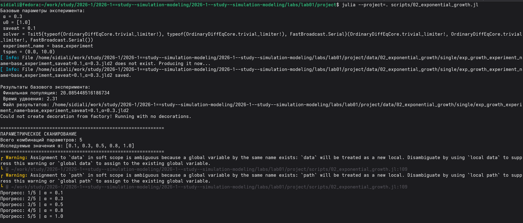

Рисунок 21: Выполнение базового эксперимента и параметрического сканирования модели

## Базовый эксперимент

- Построен график базового эксперимента при `α = 0.3`.

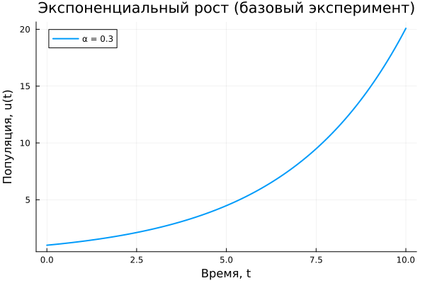

Результат базового эксперимента при α = 0.3

## Сравнение параметров модели

- Выполнено сравнение результатов для различных `α`.
- Увеличение `α` приводит к более быстрому росту популяции.

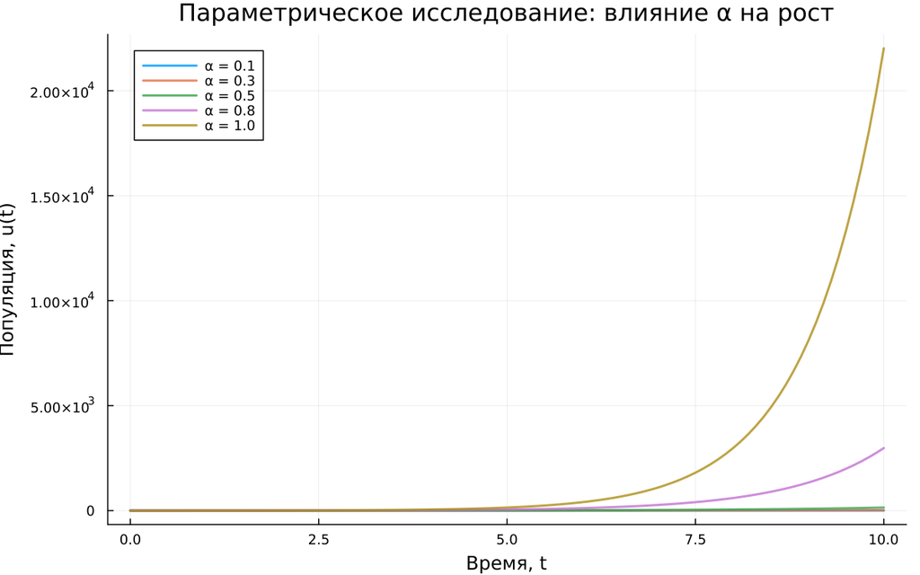

Сравнение динамики модели при различных значениях α

## Анализ времени удвоения

- Построена зависимость времени удвоения от `α`.
- Численные результаты сравнены с `t₂ = ln(2)/α`.
- При увеличении `α` время удвоения уменьшается.

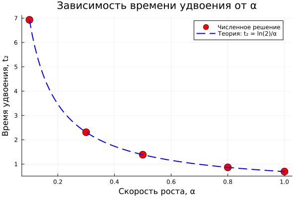

Зависимость времени удвоения от параметра α

## Анализ времени вычисления

- Построена зависимость времени вычисления от `α`.
- Сравнено время вычислений для пяти значений параметра.

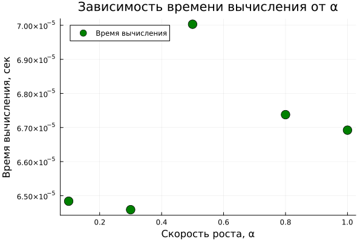

Зависимость времени вычисления от параметра α

# Литературная реализация вычислительного эксперимента

## Генерация файлов эксперимента

- `02_exponential_growth.jl` преобразован с помощью `tangle.jl`.
- Создан чистый сценарий Julia.
- Созданы документ Quarto и Jupyter Notebook.

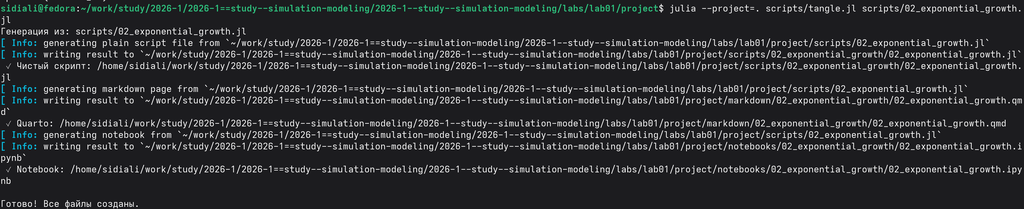

Рисунок 22: Генерация файлов литературной реализации вычислительного эксперимента

## Выполнение параметрического исследования

- Выполнен `02_exponential_growth.ipynb`.
- Получены результаты параметрического исследования.
- Выполнено сравнение численного и теоретического времени удвоения.

[figure not shown]

Рисунок 23: Выполнение параметрического исследования в Jupyter Notebook

# Выводы

- Подготовлено рабочее окружение.
- Настроены Git, GitHub и GitVerse.
- Создан и проверен проект Julia.
- Реализована модель экспоненциального роста.
- Проведено параметрическое исследование.
- При увеличении `α` рост популяции ускоряется.
- При увеличении `α` время удвоения уменьшается.
- Сформированы сценарии, документация Quarto и Jupyter Notebook.